# Homework

Jianming Wu

2021-12-21

Some codes run too long, so I annotate them.

# Hw1

## Question

Use knitr to produce at least 3 examples (texts ,figures, tables).

## Answer

### Example 1

Suppose that height and weight are linear related, set $X$ height(cm), $Y$ weight(kg), and suppose we have regression function
$$Y=50+(X-150)\times0.6$$
Now five persons’ height is 152cm, 166cm, 170cm, 178cm, 183cm, then their weight will be

```r
Height<-c(152,166,170,178,183)
Weight<-50+(Height-150)*0.6
Weight
```

```
## [1] 51.2 59.6 62.0 66.8 69.8
```

The table is shown below.

```r
library(knitr)
Weight_height_table<-data.frame(Height,Weight,row.names = c("A","B","C","D","E"))
knitr::kable(t(Weight_height_table),format = "html",caption = "Table 1: height-weight table")
```

Table 1: height-weight table

|  | A | B | C | D | E |
| --- | --- | --- | --- | --- | --- |
| Height | 152.0 | 166.0 | 170 | 178.0 | 183.0 |
| Weight | 51.2 | 59.6 | 62 | 66.8 | 69.8 |

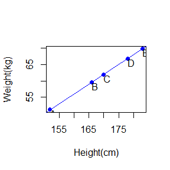

```r
library(graphics)
plot(Weight_height_table,type = "p",pch=16,col="blue",xlab = "Height(cm)",ylab = "Weight(kg)")
abline(a=-40,b=0.6,col="blue")
text(Weight_height_table,labels =c("A","B","C","D","E"),adj = c(0,1))
```

Then we can see the prediction.

# Hw2

## Question

Exercises 3.4, 3.11, and 3.20 (pages 94-96, Statistical Computing with R).

## Answers

### Exercise 3.4

The Rayleigh density is
$$f(x)=\frac{x}{\sigma^2}e^{-x^2/(2\sigma^2)},\ x{\ge}0,\sigma>0.$$

Develop an algorithm to generate random samples from a Rayleigh($\sigma$) distribution. Generate Rayleigh($\sigma$) samples for several choices of $\sigma>0$ and check that the mode of the generated samples is close to the theoretical mode $\sigma$ (check the histogram).

$\textbf{Sol.}$ The Rayleigh distribution is
$$F(x)=1-e^{-x^2/(2\sigma^2)},$$
the probability inverse transformation is
$$F^{-1}(u)=\sqrt{-2\sigma^2 \log(1-u)}.$$

So the algorithm is as follows.

$\textbf{Algorithm:}$ Generate random samples from a Rayleigh($\sigma$) distribution

$\textbf{Input:}$ positive parameter $\sigma$ and sample size $n$

$\textbf{Output:}$ $n$ samples from the Rayleigh($\sigma$) distribution

$\textbf{1}$ generate $n$ samples $U{\sim}U(0,1)$;

$\textbf{2}$ $\textbf{return}$ $X=F_{\sigma}^{-1}(U)$;

We generate 1000 random samples with $\sigma=1,2,3,4,5,6$, and we show that the mode of the generated samples is close to the theoretical mode $\sigma$ (red lines) by the histogram.

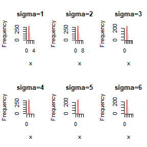

### Exercise 3.11

Generate a random sample of size 1000 from a normal location mixture. The components of the mixture have $N(0, 1)$ and $N(3, 1)$ distributions with mixing probabilities $p_1$ and $p_2 = 1 − p_1$. Graph the histogram of the sample with density superimposed, for $p_1 = 0.75$. Repeat with different values for $p_1$ and observe whether the empirical distribution of the mixture appears to be bimodal. Make a conjecture about the values of $p_1$ that produce bimodal mixtures.

$\textbf{Sol.}$ First we generate a random sample of size 1000 from a normal location mixture and graph the histogram.

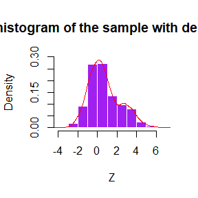

We set $p_1=0.1,0.2,0.3,0.4,0.5,0.6,0.7,0.8,0.9$, compare the histogram and density.

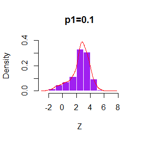

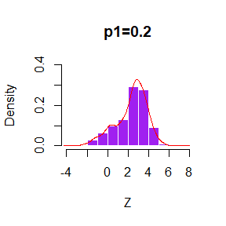

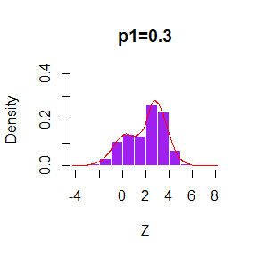

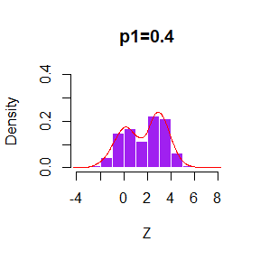

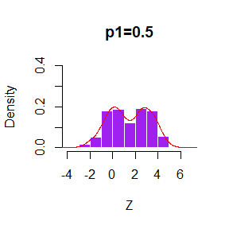

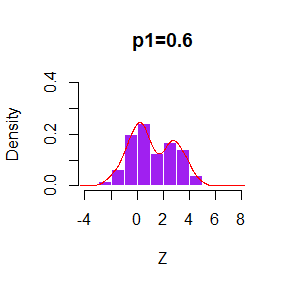

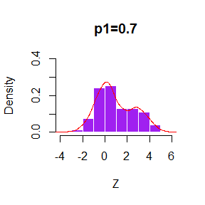

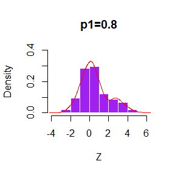

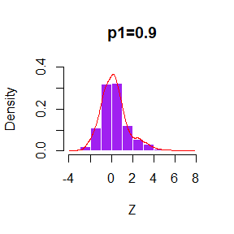

As shown above, $p_1$ is closer to 0.5, the bimodal distribution is more obvious. When $p_1{\in}(0.2,0.8)$, there exists a bimodal distribution.

### Exercise 3.20

A *compound Poisson process* is a stochastic process $\{X(t), t{\ge}0\}$ that can be represented as the random sum $X(t)=\sum_{i=1}^{N(t)}Y_i, t{\ge}0$, where $\{N(t),t{\ge}0\}$ is a Poisson process and $Y_1,Y_2,\cdots$ are iid and independent of $\{N(t),t{\ge}0\}$. Write a program to simulate a compound Poisson($\lambda$)-Gamma process ($Y$ has a Gamma distribution). Estimate the mean and the variance of $X(10)$ for several choices of the parameters and compare with the theoretical values.

$\textbf{Sol.}$ Suppose $Y{\sim}Gamma(\alpha,\beta)$, then
$$X(t)|N(t){\sim}Gamma(N(t)\alpha,\beta).$$

For given $t$, $N(t)=\sum_{i=1}^tN_i$ with $N_i\ i.i.d. {\sim} Poisson(\lambda)$, so
$$N(t){\sim}Poisson(t\lambda).$$

We define a function that the parameters are time $t$, $X(t)$ sample size $n$, Poisson parameter $\lambda$, Gamma parameters $\alpha$ and $\beta$. The output is $n$ samples of $X(t)$.

We compare the sample mean and variance and theoretical mean and variance respectively of $X(10)$ with different parameters $\lambda$, $\alpha$ and $\beta$. The theoretical mean of $X(t)$ is
$$E(X(t))=E(E(X(t)|N(t)))=\lambda t \frac{\alpha}{\beta}.$$
The theoretical variance of $X(t)$ is
$$Var(X(t))=\lambda t \frac{\alpha+\alpha^2}{\beta^2}.$$
We use relative error
$$r=\frac{\bar{X}(t)-E(X(t))}{E(X(t))}.$$
to compare means and use
$$v=\frac{\widehat{Var}(X(t))}{Var(X(t))}-1.$$
to compare variances.

First we change $\lambda=1,2,5,10$ and keep other parameters, then the relative error is $r=$ 0.0078408, -0.0090656, 0.0021267, 0.0020544 and $v=$ -0.0293713, 0.016044, -0.0035945, 0.0166239. Then we change $\alpha=1,2,5,10$, the relative error is $r=$ 0.0052, -0.0077591, -0.0042015, 0.006474 and $v=$ 0.0298427, 0.0624077, 0.0014844, 0.0104618. Last we change $\beta=1,2,5,10$, the relative error is $r=$ 0.0061575, -3.2559287^{-4}, 0.0139795, -0.0031943 and $v=$ 0.0455488, 0.054263, 0.0965498, 0.007981. The error is close to zero, so the estimators of the mean and the variance of $X(10)$ is close to the theoretical values.

# HW3

## Question

Exercises 5.4, 5.9, 5.13 and 5.14 (pages 149-151, Statistical Computing with R).

## Answer

### Exercise 5.4

Write a function to compute a Monte Carlo estimate of the Beta(3, 3) cdf, and use the function to estimate $F(x)$ for $x = 0.1, 0.2, . . ., 0.9$. Compare the estimates with the values returned by the $pbeta$ function in R.

$\textbf{Sol.}$ The Beta(3,3) cdf is
$$F(x)=\int_0^{x}\frac{\Gamma(6)}{\Gamma(3)\Gamma(3)}t^2(1-t)^2dt=\int_0^x30t^2(1-t)^2dt.$$

```r
Beta.est<-function(x){
  if(x>1||x<0)
    print("Error input!")
  else {
    u<-runif(1000,min = 0,max = x)
    return(mean(30*u^2*(1-u)^2*x))
  }
}
x<-seq(0.1,0.9,by=0.1)
Mat<-matrix(0,9,3)
colnames(Mat)<-c("x","estimation","difference")
# Compare the estimates with the values returned by the pbeta function
for (i in 1:9) {
  Mat[i,1]<-x[i]
  Mat[i,2]<-Beta.est(x[i])
  Mat[i,3]<-Beta.est(x[i])-pbeta(x[i],3,3)
}
Mat
```

```
##         x  estimation   difference
##  [1,] 0.1 0.008443812 -0.000449306
##  [2,] 0.2 0.059420086  0.001745357
##  [3,] 0.3 0.158980770 -0.006033530
##  [4,] 0.4 0.316807468  0.005449907
##  [5,] 0.5 0.519394187  0.021388607
##  [6,] 0.6 0.684160841  0.003879313
##  [7,] 0.7 0.851324298 -0.005073113
##  [8,] 0.8 0.923640698  0.003300447
##  [9,] 0.9 0.979692579 -0.009677036
```

The second column above is the estimation for different $x$, the third column is the difference between our function and $pbeta$ function. The difference is small!

### Exercise 5.9

The Rayleigh density [156, (18.76)] is
$$f(x)=\frac{x}{\sigma^2}e^{-x^2/(2\sigma^2)},\ x{\ge}0,\sigma>0.$$
Implement a function to generate samples from a Rayleigh($σ$) distribution, using antithetic variables. What is the percent reduction in variance of $\frac{X+X'}{2}$ compared with $\frac{X_1+X_2}{2}$ for independent $X_1, X_2$?

$\textbf{Sol.}$ The Rayleigh distribution is
$$F(x)=1-e^{-x^2/(2\sigma^2)},$$
the probability inverse transformation is
$$F^{-1}(u)=\sqrt{-2\sigma^2 \log(1-u)}.$$
The function to generate samples from a Rayleigh($σ$) distribution using antithetic variables is written in $R$.

```r
Gen_Ray_ant<-function(sigma=sigma,n=n,antithetic = TRUE){
  if(n%%2!=0 && antithetic)
    print("Error size!")
  else if(!antithetic) {
      u<-runif(n/2)
      v<-runif(n/2)
      return(list(X1=sqrt(-2*sigma^2*log(1-u)),X2=sqrt(-2*sigma^2*log(1-v))))
  } else {
      u<-runif(n/2)
      return(list(X1=sqrt(-2*sigma^2*log(1-u)),X2=sqrt(-2*sigma^2*log(u))))
        }
}
```

```r
library(scales)
#antithetic variable
set.seed(2001)
Result_ant<-Gen_Ray_ant(sigma = 2,n=500,antithetic = TRUE)
X1_ant<-Result_ant$X1
X2_ant<-Result_ant$X2
print(var_ant<-var((X1_ant+X2_ant)/2))
```

```
## [1] 0.04923363
```

```r
#non-antithetic
set.seed(2002)
Result_non<-Gen_Ray_ant(sigma = 2,n=500,antithetic = FALSE)
X1_non<-Result_non$X1
X2_non<-Result_non$X2
print(var_non<-var((X1_non+X2_non)/2))
```

```
## [1] 0.8448747
```

```r
# compute percent reduction
print((var_non-var_ant)/var_non)
```

```
## [1] 0.9417267
```

The variances of $\frac{X+X'}{2}$ and $\frac{X_1+X_2}{2}$ are simulated. The percent reduction is about 94.17%.

### Exercise 5.13

Find two importance functions $f_1$ and $f_2$ that are supported on $(1,\infty)$ and are ‘close’ to
$$g(x) =\frac{x^2}{\sqrt{2\pi}}e^{-x^2/2},\ x>1.$$
Which of your two importance functions should produce the smaller variance in estimating
$$\int_1^{\infty}\frac{x^2}{\sqrt{2\pi}}e^{-x^2/2}dx$$
by importance sampling? Explain.

$\textbf{Sol.}$We set importance functions
$$f_1(x)=\sqrt{e}xe^{-x^2/2},\ \ x>1,$$
and
$$f_2(x)=\frac{\sqrt{e}x^3}{3}e^{-x^2/2},\ \ x>1.$$
With the same sample size $m$, the variance of $\hat{\theta}$ is $var(g(X)/f_i(X))/m$ where $X$ has pdf $f_i(\cdot)$. The mean of $\hat{\theta}$ is $E(g(X)/f_i(X))=\int_1^\infty g(x)dx$, so we can only compare the second order moment.
$$E(g(X)/f_1(X))^2=\frac{3}{2\pi e},$$
and
$$E(g(X)/f_2(X))^2=\frac{3}{2\pi e}.$$
Therefore, the importance functions $f_1$ and $f_2$ produce the same variance in estimating the integration.

### Exercise 5.14

Obtain a Monte Carlo estimate of
$$\int_1^{\infty}\frac{x^2}{\sqrt{2\pi}}e^{-x^2/2}dx$$
by importance sampling.

$\textbf{Sol.}$We use importance function $f_1(x)=\sqrt{e}xe^{-x^2/2}$ for simulation to estimate the integration.

```r
set.seed(10086)
u<-runif(1000)
theta.hat<-sqrt(1-2*log(1-u))/sqrt(2*pi*exp(1))
theta.est<-mean(theta.hat)
```

The Monte Carlo estimate is 0.4013146.

# HW4

## Questions

1. Exercises 6.5 and 6.A (page 180-181, Statistical Computating with R).
2. If we obtain the powers for two methods under a particular simulation setting with 10,000 experiments: say, 0.651 for one method and 0.676 for another method. We want to know if the powers are different at 0.05 level.

(1) What is the corresponding hypothesis test problem?

(2) What test should we use? Z-test, two-sample t-test, paired-t test or McNemar test? Why?

(3) Please provide the least necessary information for hypothesis testing.

## Answers

### Exercise 6.5

Suppose a 95% symmetric $t$-interval is applied to estimate a mean, but the sample data are non-normal. Then the probability that the confidence interval covers the mean is not necessarily equal to 0.95. Use a Monte Carlo experiment to estimate the coverage probability of the $t$-interval for random samples of $\chi^2(2)$ data with sample size $n = 20$. Compare your $t$-interval results with the simulation results in Example 6.4. (The $t$-interval should be more robust to departures from normality than the interval for variance.)

$\textbf{Sol.}$ Suppose $X_1,\cdots,X_n$ has a distribution of $\chi^2(2)$, the symmetric $t$-interval supposes that $\sqrt{n}(\bar{X}-\mu)/S{\sim}t_{n-1}$, then the $(1-\alpha)\%$ symmetric $t$-interval is $\left[\bar{X}-\frac{S}{\sqrt{n}}t_{n-1}(\frac{\alpha}{2}),\bar{X}+\frac{S}{\sqrt{n}}t_{n-1}(\frac{\alpha}{2})\right]$ and the UCL is $\bar{X}+\frac{S}{\sqrt{n}}t_{n-1}(\alpha)$. The mean of $\chi^2(2)$ is 2. We use R to calculate the CI.

```r
n<-20
alpha<-.05
UCL<-U<-V<-numeric(1000)
for (i in 1:1000){
  x<-rchisq(n,2)
  U[i]<-mean(x)+sd(x)/sqrt(n)*qt(alpha/2,df=n-1)
  V[i]<-mean(x)-sd(x)/sqrt(n)*qt(alpha/2,df=n-1)
  UCL[i]<-mean(x)-sd(x)/sqrt(n)*qt(alpha,df=n-1)
}
```

### Project 6.A

Use Monte Carlo simulation to investigate whether the empirical Type I error rate of the $t$-test is approximately equal to the nominal significance level $\alpha$, when the sampled population is non-normal. The $t$-test is robust to mild departures from normality. Discuss the simulation results for the cases where the sampled population is (i) $\chi^2(1)$, (ii) $Uniform(0,2)$, and (iii) $Exponential(rate=1)$. In each case, test $H_0 : \mu = \mu_0\ \text{vs}\ H_0 : \mu = \mu_0$, where $\mu_0$ is the mean of $\chi^2(1)$, $Uniform(0,2)$, and $Exponential(1)$, respectively.

$\textbf{Sol.}$ Suppose $X_1,\cdots,X_n$ has a distribution of $F$, the $t$ test for null hypothesis $H_0:\mu=\mu_0$ is when $\left|\frac{\sqrt{n}(\bar{X}-\mu_0)}{S}\right|>t_{n-1}(\alpha/2)$, we reject the null hypothesis.

$(i)$ The mean of $\chi^2(1)$ is 1, so the hypothesis is
$$H_0:\mu=1{\leftrightarrow}H_1:\mu{\ne}1.$$
The rejection region is $\left\{X_1,\cdots,X_n:\left|\frac{\sqrt{n}(\bar{X}-1)}{S}\right|>t_{n-1}(\alpha/2)\right\}$, and the Type I error rate is $P_{H_0}(\text{rejection region})$. We choose sample size 200 and 20 to simulate the effect of sample size.

```r
n<-200
mu0<-1
m<-500
Ind<-numeric(m)
for (i in 1:m) {
  x<-rchisq(n,df=1)
  Ind[i]<-t.test(x, mu = mu0)$p.value
}
```

The t1e rate is approximately 0.044 which is similar to $\alpha=0.05$.

```r
l<-20
Ind<-numeric(m)
for (i in 1:m) {
  x<-rchisq(l,df=1)
  Ind[i]<-t.test(x, mu = mu0)$p.value
}
```

The t1e rate is approximately 0.1 which is greater than $\alpha=0.05$.

$(ii)$ The mean of $Uniform(0,2)$ is 1, so the hypothesis is
$$H_0:\mu=1{\leftrightarrow}H_1:\mu{\ne}1.$$
The rejection region is $\left\{X_1,\cdots,X_n:\left|\frac{\sqrt{n}(\bar{X}-1)}{S}\right|>t_{n-1}(\alpha/2)\right\}$, and the Type I error rate is $P_{H_0}(\text{rejection region})$.

```r
Ind<-numeric(m)
for (i in 1:m) {
  x<-runif(n,min = 0,max = 2)
  Ind[i]<-t.test(x, mu = mu0)$p.value
}
```

The t1e rate is approximately 0.042 which is similar to $\alpha=0.05$.

```r
Ind<-numeric(m)
for (i in 1:m) {
  x<-runif(l,min = 0,max = 2)
  Ind[i]<-t.test(x, mu = mu0)$p.value
}
```

The t1e rate is approximately 0.052 which is similar to $\alpha=0.05$.

$(iii)$ The mean of $Exp(1)$ is 1, so the hypothesis is
$$H_0:\mu=1{\leftrightarrow}H_1:\mu{\ne}1.$$
The rejection region is $\left\{X_1,\cdots,X_n:\left|\frac{\sqrt{n}(\bar{X}-1)}{S}\right|>t_{n-1}(\alpha/2)\right\}$, and the Type I error rate is $P_{H_0}(\text{rejection region})$.

```r
Ind<-numeric(m)
for (i in 1:m) {
  x<-rexp(n,rate = 1)
  Ind[i]<-t.test(x, mu = mu0)$p.value
}
```

The t1e rate is approximately 0.058 which is similar to $\alpha=0.05$.

```r
Ind<-numeric(m)
for (i in 1:m) {
  x<-rexp(l,rate = 1)
  Ind[i]<-t.test(x, mu = mu0)$p.value
}
```

The t1e rate is approximately 0.084 which is greater than $\alpha=0.05$.

Therefore, the answer is obvious, when the distribution is non-normal and the sample size is large the t1e rate of $t$-test is approximately equal to $\alpha$. This result can be explained by the Center Limitation Theorem. But when the sample size is small the variables from $\chi^2(1)$ and $Exp(1)$ are far from normal distribution, so the Type I error rate is much greater than $\alpha$.

### Exercise 3

(1) Let $p_i$ be the probability of rejection region from method $i$ when the alternative hypothesis is true. Then to test where the powers for two methods is equal the null hypothesis is $H_0:p_1=p_2$. The alternative hypothesis is that they are different.

(2) We can use the $\textbf{McNemar test}$ because this is a binary classification with two methods. And the variables are related because in each experiment the observation $x$ is used in both method.

(3) To use the McNemar test, we have to know among 10000 experiment, how much times method one rejects $H_0'$ but method two accepts it under condition of $H_1'$, suppose $n_{12}$, how much times method one accepts $H_0'$ but method two rejects it under condition of $H_1'$, suppose $n_{21}$. Then we can calculate $T=\frac{(n_{12}-n_{21})^2}{n_{12}+n_{21}}$, which has a approximate distribution of $\chi_1^2$. If $T>\chi_1^2(\alpha)$ we reject $H_0$.

# hw5

## Question 6.C

Repeat Examples 6.8 and 6.10 for Mardia’s multivariate skewness test. Mardia [187] proposed tests of multivariate normality based on multivariate generalizations of skewness and kurtosis. If $X$ and $Y$ are iid, the multivariate population skewness $\beta_{1,d}$ is defined by Mardia as
$$\beta_{1,d} = E[(X-\mu)^T\Sigma^{-1}(Y-\mu)]^3.$$
Under normality, $\beta_{1,d}$ = 0. The multivariate skewness statistic is
$$b_{1,d}=\frac{1}{n^2}\sum_{i,j=1}^{n}((X_i-\bar{X})^T{\widehat{\Sigma}}^{-1}(X_j-\bar{X}))^3,$$
where $\widehat{\Sigma}$ is the maximum likelihood estimator of covariance. Large values of $b_{1,d}$ are significant. The asymptotic distribution of $nb_{1,d}/6$ is chisquared with $d(d + 1)(d + 2)/6$ degrees of freedom.

## Answer

The hypothesis test is
$$H_0:\beta_{1,d}=0;{\leftrightarrow}\beta_{1,d}{\ne}0.$$
If the multivariate skewness statistic $b_{1,d}>\text{some\ }C$, we reject $H_0$. Notice the asymptotic distribution of $nb_{1,d}/6$ is chisquared with $d(d + 1)(d + 2)/6$ degrees of freedom. Therefore if $nb_{1,d}/6>\chi_{t}^2(\alpha),\ t=d(d + 1)(d + 2)/6$we reject $H_0$. Set $d=2,\alpha=0.05$,$\mu^T=[0,1],\Sigma=\begin{pmatrix} 1&0.8\\ 0.8&2 \end{pmatrix}$ ,we generate n samples with $N_2(\mu,\Sigma)$.

```r
n<-c(10,20,30,50,100,500)#sample size
d<-2#dimension
cv<-qchisq(0.95,d*(d+1)*(d+2)/6)
rmvn.eigen <- function(n, mu, Sigma) {
# generate random vectors from MVN(mu, Sigma)
# dimension is inferred from mu and Sigma
d <- length(mu)
ev <- eigen(Sigma, symmetric = TRUE)
lambda <- ev$values
V <- ev$vectors
C <- V %*% diag(sqrt(lambda)) %*% t(V)
Z <- matrix(rnorm(n*d), nrow = n, ncol = d)
X <- Z %*% C + matrix(mu, n, d, byrow = TRUE)
X
}
mu<-c(0,1)
Sigma <- matrix(c(1, .8, .8, 2), nrow = 2, ncol = 2)
#a function to calculate the multivariate skewness statistic
mulss<-function(x){
  mu.bar<-apply(x, 2,mean)
  num<-nrow(x)
  cov.hat.inv<-solve((num-1)/num*cov(x))
  x.t<-t(x)-mu.bar
  x.mat<-t(x.t)%*%cov.hat.inv%*%x.t
  return(sum(x.mat^3)/(num^2))
}
p.reject<-numeric(length(n))#to store sim. results
m<-1e3#num. repl. each sim.
for (i in 1:length(n)) {
  mdtests<-numeric(m)
  for (j in 1:m) {
    x<-rmvn.eigen(n[i],mu,Sigma)
    mdtests[j] <- as.integer(n[i]*mulss(x)/6 >= cv )
  }
  p.reject[i]<-mean(mdtests)
}
p.reject
```

```
## [1] 0.006 0.033 0.039 0.040 0.051 0.045
```

For different $n=$10, 20, 30, 50, 100, 500, the Type I error rates are respectively 0.006, 0.033, 0.039, 0.04, 0.051, 0.045. When $n$ is large, the Type I error rate is approximately equal to $\alpha$.

Like Example 6.10, we consider the contaminated multivariate normal distribution
$$\epsilon N_2(0,\Sigma_1)+(1-\epsilon)N_2(0,\Sigma_2),\ 0{\le}\epsilon{\le}1.$$
We set $\Sigma_1=\begin{pmatrix} 1&0.8\\ 0.8&2 \end{pmatrix}$and $\Sigma_2=\begin{pmatrix} 100&80\\ 80&200 \end{pmatrix}$. The sample size is $n=40$, and significance level is $\alpha=0.1$. We plot the power curve for different $\epsilon$.

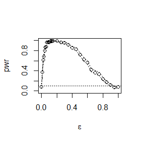

```r
alpha <- .1
n <- 40
m <- 200
Sigma1<-matrix(c(1,0.8,0.8,2),2,2)
Sigma2<-matrix(c(100,80,80,200),2,2)
epsilon <- c(seq(0, .15, .01), seq(.15, 1, .05))
N <- length(epsilon)
pwr <- numeric(N)
#critical value for the skewness test
cv <- qchisq(1-alpha,d*(d+1)*(d+2)/6)
for (j in 1:N) { #for each epsilon
e <- epsilon[j]
mdtests <- numeric(m)
for (i in 1:m) { #for each replicate
index<- sample(c(1,2), replace = TRUE, size = n, prob = c(1-e, e))
x<-matrix(0,n,d)
for (k in 1:n) {
  if(index[k]==1) x[k,]=rmvn.eigen(1,c(0,0),Sigma1)
  if(index[k]==2) x[k,]=rmvn.eigen(1,c(0,0),Sigma2)
}
mdtests[i] <- as.integer(n*mulss(x)/6> cv)
}
pwr[j] <- mean(mdtests)
}
#plot power vs epsilon
plot(epsilon, pwr, type = "b", xlab = bquote(epsilon), ylim = c(0,1))
abline(h = .1, lty = 3)
se <- sqrt(pwr * (1-pwr) / m) #add standard errors
lines(epsilon, pwr+se, lty = 3)
lines(epsilon, pwr-se, lty = 3)
```

As is shown, the power curve crosses the horizontal line corresponding to $\alpha = 0.10$ at both endpoints, $\epsilon$=0 and $\epsilon$=1 where the alternative is normally distributed. For $0<\epsilon< 1$ the empirical power of the test is greater than 0.10 and highest when $\epsilon$ is about 0.15.

# HW6

## Exercise 7.7

Refer to Exercise 7.6. Efron and Tibshirani discuss the following example [84, Ch. 7]. The five-dimensional scores data have a 5 × 5 covariance matrix $\Sigma$, with positive eigenvalues $\lambda_1 >\cdots> \lambda_5$. In principal components analysis,
$$\theta=\frac{\lambda_1}{\sum_{i=1}^5\lambda_i}$$
measures the proportion of variance explained by the first principal component. Let $\hat{\lambda}_1 >\cdots > \hat{\lambda}_5$ be the eigenvalues of $\hat\Sigma$, where $\hat{\Sigma}$ is the MLE of $\Sigma$. Compute the sample estimate
$$\hat{\theta}=\frac{\hat\lambda_1}{\sum_{i=1}^5\hat\lambda_i}$$
of $\theta$. Use bootstrap to estimate the bias and standard error of $\hat{\theta}$.

$\textbf{Sol.}$

```r
data(scor,package="bootstrap")
n<-nrow(scor)
p<-ncol(scor)
Cova_scor<-(n-1)/n*cov(scor)#MLE
eigen_value_scor<-eigen(Cova_scor)
eigen_value_scor<-eigen_value_scor$values
Theta<-eigen_value_scor[1]/sum(eigen_value_scor)
print(Theta)
```

```
## [1] 0.619115
```

```r
#Bootstrap
B<-500
R<-numeric(B)
for (b in 1:B) {
  i<-sample(1:n,size = n,replace = TRUE)
  Scor<-scor[i,]
  eign<-eigen((n-1)/n*cov(Scor))$values
  R[b]<-eign[1]/sum(eign)
}
print(se.R<-sd(R))
```

```
## [1] 0.04678636
```

```r
bias.Boot<-mean(R)-Theta
print(bias.Boot)
```

```
## [1] -0.001524881
```

## Exercise 7.8

Refer to Exercise 7.7. Obtain the jackknife estimates of bias and standard error of $\hat{\theta}$.

$\textbf{Sol.}$

```r
Theta.jack<-numeric(n)
for (i in 1:n) {
  Scor_i<-scor
  Cova<-cov(Scor_i[-i,])
  eig<-eigen((n-2)/(n-1)*Cova)$values
  Theta.jack[i]<-eig[1]/sum(eig)
}
bias<-(n-1)*(mean(Theta.jack)-Theta)
print(bias)
```

```
## [1] 0.001069139
```

```r
se.jack<-sqrt((n-1)*mean((Theta.jack-mean(Theta.jack))^2))
print(se.jack)
```

```
## [1] 0.04955231
```

The estimation of bias is 0.0010691, and the estimation of standard error is 0.0495523.

## Exercise 7.9

Refer to Exercise 7.7. Compute 95% percentile and BCa confidence intervals for $\hat{\theta}$.

$\textbf{Sol.}$ We use the bootstrap sample in Exercise 7.7 and 7.8.

```r
# 95% percentile CI
alpha<-c(.025,.975)
print(quantile(R,alpha,type=6))
```

```
##      2.5%     97.5%
## 0.5213394 0.7119348
```

```r
# BCa
Z0<-qnorm(mean(as.integer(R<Theta)))
Zalpha<-qnorm(alpha)
L<-mean(Theta.jack)-Theta.jack
a<-sum(L^3)/(6*sum(L^2)^1.5)
adj.alpha <- pnorm(Z0 + (Z0+Zalpha)/(1-a*(Z0+Zalpha)))# adjusted alpha
adj.alpha
```

```
## [1] 0.02830132 0.97819754
```

```r
BCa<-quantile(R,adj.alpha,type = 6)
```

The 95% percentile CI is $(0.5213394, 0.7119348)$. The BCa CI is $(0.5221525, 0.7140726)$.

## Project 7.B

Repeat Project 7.A for the sample skewness statistic. Compare the coverage rates for normal populations (skewness 0) and $\chi^2_5$ distributions (positive skewness).

```r
library(boot)
size<-1e2 #sample size
# sample skewness
sk <- function(x,i) {
  xbar <- mean(x[i])
  m3 <- mean((x[i] - xbar)^3)
  m2 <- mean((x[i] - xbar)^2)
  return( m3 / m2^1.5 )
}
# empirical CP
CPnm.norm<-CPnm.perc<-CPnm.basic<-numeric(1e2)
for (i in 1:1e2) {
# normal population
nmdata<-rnorm(size)
boot.nm<-boot(nmdata,statistic = sk,R=1e2)
bootnm.ci<-boot.ci(boot.nm,type = c("norm","basic","perc"))
CPnm.norm[i]<-as.integer(boot.nm$t0>bootnm.ci$normal[2]&boot.nm$t0<bootnm.ci$normal[3])
CPnm.perc[i]<-as.integer(boot.nm$t0>bootnm.ci$percent[4]&boot.nm$t0<bootnm.ci$percent[5])
CPnm.basic[i]<-as.integer(boot.nm$t0>bootnm.ci$basic[4]&boot.nm$t0<bootnm.ci$basic[5])
}
print(c(mean(CPnm.norm),mean(CPnm.basic),mean(CPnm.perc)))
```

```
## [1] 1 1 1
```

```r
# chi distribution
# empirical CP
CPchi.norm<-CPchi.perc<-CPchi.basic<-numeric(1e2)
for (i in 1:1e2) {
  datachi<-rchisq(size,5)
  # chi population
  bootchi<-boot(datachi,statistic = sk,R=1e2)
  bootchi.ci<-boot.ci(bootchi,type =  c("norm","basic","perc"))
  CPchi.norm[i]<-as.integer(bootchi$t0>bootchi.ci$normal[2]&bootchi$t0<bootchi.ci$normal[3])
  CPchi.perc[i]<-as.integer(bootchi$t0>bootchi.ci$percent[4]&bootchi$t0<bootchi.ci$percent[5])
  CPchi.basic[i]<-as.integer(bootchi$t0>bootchi.ci$basic[4]&bootchi$t0<bootchi.ci$basic[5])
}
print(c(mean(CPchi.norm),mean(CPchi.basic),mean(CPchi.perc)))
```

```
## [1] 1 1 1
```

For the standard normal population, the CPs of the standard normal bootstrap confidence interval, the basic bootstrap confidence interval and the percentile confidence interval are 1, 1, 1 respectively.

For the $\chi_5^2$ population, the CPs of the standard normal bootstrap confidence interval, the basic bootstrap confidence interval and the percentile confidence interval are 1, 1, 1 respectively.

# HW7

## Exercise 8.2

Implement the bivariate Spearman rank correlation test for independence [255] as a permutation test. The Spearman rank correlation test statistic can be obtained from function `cor` with `method = "spearman"`. Compare the achieved significance level of the permutation test with the $p$-value reported by `cor.test` on the same samples.

$\textbf{Sol.}$

```r
## generate two group sample randomly
n1<-20
n<-2*n1
K<-1:n
R<-499
x1<-runif(n1)
x2<-rexp(n1)
z<-c(x1,x2)
## calculate original Spearman rank correlation test statistic and p-value
t0<-cor(x1,x2,method = "spearman")
p0<-cor.test(x1,x2,method="spearman")$p.value
reps<-numeric(R)
set.seed(20211104)
for (i in 1:R) {
  k <- sample(K, size =n1, replace = FALSE)
  y1 <- z[k]
  y2 <- z[-k]
  reps[i]<-cor(y1,y2,method = "spearman")
}
p<-mean(abs(c(t0,reps))>abs(t0))# p-value calculated by permutation test
round(c(p,p0),4)
```

```
## [1] 0.4580 0.4762
```

The achieved significance level of the permutation test and the $p$-value reported by `cor.test` on the same samples are very similar.

## Exercise 2

Design experiments for evaluating the performance of the NN, energy, and ball methods in various situations.

1. Unequal variances and equal expectations
2. Unequal variances and unequal expectations
3. Non-normal distributions: $t$ distribution with 1 df (heavy-tailed distribution), bimodel distribution (mixture of two normal distributions)
4. Unbalanced samples (say, 1 case versus 10 controls)
5. Note: The parameters should be chosen such that the powers are distinguishable (say, range from 0.3 to 0.8).

$\textbf{Sol.}$ Consider hypothesis test that two multivariate distributions are equal. The sample is generated by two-dimensional normal distribution.

```r
library(energy)
library(Ball)
library(boot)
library(RANN)
m <-500
k<-3
p<-2
mu<-0.3
set.seed(12345)
n1<-50
n2<-100
R<-499
n <- n1+n2
## Tn function
Tn <- function(z, ix, sizes,k) {
  n1 <- sizes[1]
  n2 <- sizes[2]
  n <- n1 + n2
  if(is.vector(z)) z <- data.frame(z)
  z <- z[ix, ]
  NN <- nn2(data=z, k=k+1)
  block1 <- NN$nn.idx[1:n1,-1]
  block2 <- NN$nn.idx[(n1+1):n,-1]
  i1 <- sum(block1 <= n1)
  i2 <- sum(block2 > n1)
  (i1 + i2) / (k * n)
}
## the NN method
eqdist.nn <- function(z,sizes,k){
  boot.obj <- boot(data=z,statistic=Tn,R=R,
  sim = "permutation", sizes = sizes,k=k)
  ts <- c(boot.obj$t0,boot.obj$t)
  p.value <- mean(ts>=ts[1])
  list(statistic=ts[1],p.value=p.value)
}
```

### Unequal variances and equal expectations

```r
N<-c(n1,n1)
p.values <- matrix(NA,m,3)
for(i in 1:m){
x<-matrix(rnorm(n1*p,0,1.5),ncol=p)
y<-matrix(rnorm(n1*p,0,2),ncol = p)
#y <- cbind(rnorm(n2),rnorm(n2,mean=mu));
z <- rbind(x,y)
p.values[i,1] <- eqdist.nn(z,N,k)$p.value
p.values[i,2] <- eqdist.etest(z,sizes=N,R=R)$p.value
p.values[i,3] <- bd.test(x=x,y=y,num.permutations=R,
seed=i*12345)$p.value
}
alpha <- 0.1
pow <- colMeans(p.values<alpha)
pow<-data.frame(pow)
rownames(pow)<-c("NN","Energy","Ball")
colnames(pow)<-c("power")
knitr::kable(t(pow))
```

|  | NN | Energy | Ball |
| --- | --- | --- | --- |
| power | 0.298 | 0.324 | 0.728 |

### Unequal variances and unequal expectations

```r
N<-c(n1,n1)
p.values <- matrix(NA,m,3)
for(i in 1:m){
x<-matrix(rnorm(n1*p,0,1.5),ncol=p)
y<-matrix(rnorm(n1*p,mu,2),ncol = p)
#y <- cbind(rnorm(n2),rnorm(n2,mean=mu));
z <- rbind(x,y)
p.values[i,1] <- eqdist.nn(z,N,k)$p.value
p.values[i,2] <- eqdist.etest(z,sizes=N,R=R)$p.value
p.values[i,3] <- bd.test(x=x,y=y,num.permutations=R,
seed=i*12345)$p.value
}
alpha <- 0.1
pow <- colMeans(p.values<alpha)
pow<-data.frame(pow)
rownames(pow)<-c("NN","Energy","Ball")
colnames(pow)<-c("power")
knitr::kable(t(pow))
```

|  | NN | Energy | Ball |
| --- | --- | --- | --- |
| power | 0.312 | 0.496 | 0.75 |

# HW8

## Exercise 9.3

Use the Metropolis-Hastings sampler to generate random variables from a standard Cauchy distribution. Discard the first 1000 of the chain, and compare the deciles of the generated observations with the deciles of the standard Cauchy distribution (see `qcauchy` or `qt` with df=1). Recall that a Cauchy($\theta$,$\eta$) distribution has density function
$$f(x)=\frac{1}{{\theta}{\pi}(1+[(x-\eta)/{\theta}]^2)},\ -\infty<x<\infty,\theta>0.$$
The standard Cauchy has the Cauchy($\theta$= 1,$\eta$= 0) density. (Note that the standard Cauchy density is equal to the Student t density with one degree of freedom.)

$\textbf{Sol.}$ First we write the Cauchy density function.

```r
fcauchy<-function(x,theta,eta){
  stopifnot(theta>0)
  f<-1/(theta*pi*(1+((x-eta)/theta)^2))
  return(f)
}
```

Then we consider standard Cauchy distribution, and we set the proposal pdf $g(\cdot |X)$ to be the density of $N(X,100)$.

```r
set.seed(10006)
N<-1000# 500 to be discarded
x<-numeric(N)
x[1]<-rnorm(1,0,2)
theta<-1
eta<-0
sd<-10
u<-runif(N)
k<-0
for (i in 2:N) {
  xt<-x[i-1]
  y<-rnorm(1,xt,sd)
  num<-fcauchy(y,theta,eta)*dnorm(xt,mean = y,sd=sd)
  den<-fcauchy(xt,theta,eta)*dnorm(y,mean = xt,sd=sd)
  if (u[i] <= num/den){
      x[i] <- y
  } else {
      x[i] <- xt
      k<-k+1
  }
}
x.new<-x[-(1:500)]# discard the first 500 samples
perc<-seq(.1,.9,.1)
Result<-data.frame(matrix(NA,2,9))
Result[1,]<-round(quantile(x.new,probs=perc),4)
Result[2,]<-round(qcauchy(perc),4)
colnames(Result)<-c("10%","20%","30%","40%","50%","60%","70%","80%","90%")
rownames(Result)<-c("MCMC","Cauchy")
knitr::kable(Result)
```

|  | 10% | 20% | 30% | 40% | 50% | 60% | 70% | 80% | 90% |
| --- | --- | --- | --- | --- | --- | --- | --- | --- | --- |
| MCMC | -2.4372 | -1.0958 | -0.5269 | -0.3041 | -0.1492 | 0.5841 | 1.0146 | 1.4391 | 2.8964 |
| Cauchy | -3.0777 | -1.3764 | -0.7265 | -0.3249 | 0.0000 | 0.3249 | 0.7265 | 1.3764 | 3.0777 |

Finally we use the Gelman-Rubin method to monitor convergence of the chain, and run the chain until it converges approximately to the target distribution according to $\hat{R}<1.2$. We set the proposal distribution $g(\cdot |X_t)$ to be Cauchy distribution with location $\eta=X_t$ and $\theta=1$.

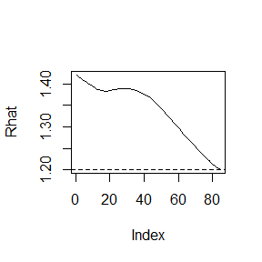

```r
set.seed(13010)
Gelman.Rubin <- function(psi) {
    # psi[i,j] is the statistic psi(X[i,1:j])
    # for chain in i-th row of X
    if(is.vector(psi)==T) psi <- t(as.matrix(psi))
    n <- ncol(psi)
    k <- nrow(psi)

    psi.means <- rowMeans(psi)     #row means
    B <- n * var(psi.means)        #between variance est.
    psi.w <- apply(psi, 1, "var")  #within variances
    W <- mean(psi.w)               #within est.
    v.hat <- W*(n-1)/n + (B/n)     #upper variance est.
    r.hat <- v.hat / W             #G-R statistic
    return(r.hat)
}
cauchy.chain<-function(theta,eta,sd,N,x1){
## sd is the sd of proposal function, N is size,
## x1 is the initial value

## return chains and psi
k<-length(x1)
x<-numeric(N)
chain<-matrix(NA,k,N)
chain[,1]<-x1
u<-matrix(runif(N*k),k,N)
psi<-matrix(NA,k,N)
psi[,1]<-x1
Count<-1
rhat <- rep(0,N)
for (i in 2:N) {
  for (j in 1:k) {
  xt<-chain[j,i-1]
  y<-rcauchy(1,location=xt)
  num<-fcauchy(y,theta,eta)*dcauchy(xt,location=y)
  den<-fcauchy(xt,theta,eta)*dcauchy(y,location=xt)
  if (u[j,i] <= num/den){
      chain[j,i] <- y
  } else {
      chain[j,i] <- xt
  }
  psi[j,i]<-mean(chain[j,1:i])
  }
  rhat[i]<-Gelman.Rubin(psi[,1:i])
  if(rhat[i]<=1.2) break;# when rhat <=1.2, stop running the chains
  Count<-i
  }
return(list(chain=chain[,1:Count],rhat=rhat[1:Count]))
}
x0<-c(-5,-2,2,5)
#x0<-c(-5,0,5)
theta<-1
eta<-0
sd<-2
n<-2000
b<-100 # burn-in length
result_CC<-cauchy.chain(theta,eta,sd,n,x0)
## result_CC contains the chains with different initial values and the rhat vector
plot(result_CC$rhat[-(1:b)],type="l",ylab = "Rhat")
abline(h=1.2, lty=2)
```

We choose 4 different initial value , the $\hat{R}$ is below 1.2 when the time $t=$ 184.

## Exercise 9.8

This example appears in [40]. Consider the bivariate density
$$f(x, y)\propto \begin{pmatrix}
n\\
x \end{pmatrix}y^{x+a−1}(1 − y)^{n−x+b−1},\ x = 0, 1,\cdots,n, 0 ≤ y ≤ 1.$$
It can be shown (see e.g. [23]) that for fixed $a, b, n$, the conditional distributions are $Binomial(n, y)$ and $Beta(x+ a, n − x+ b)$. Use the Gibbs sampler to generate a chain with target joint density $f(x, y)$.

```r
set.seed(11002)
a<-2
b<-2
n<-20
N<-1000
burn<-100
y<-x<-numeric(N)
x[1]<-x0<-0
y[1]<-y0<-0.2
for (i in 2:N) {
  yt<-y[i-1]
  xt<-x[i]<-rbinom(1,n,yt)
  y[i]<-rbeta(1,xt+a,n-xt+b)
}
chain<-cbind(x,y)
colMeans(chain)
```

```
##         x         y
## 9.1860000 0.4640128
```

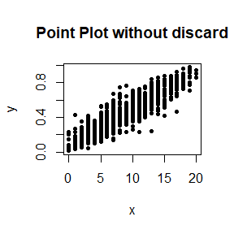

```r
plot(chain,type = "p",pch=20,main = "Point Plot without discard")
```

```r
## discard the first 1000 samples
chain.new<-chain[-(1:burn),]
colMeans(chain.new)
```

```
##         x         y
## 9.3622222 0.4721964
```

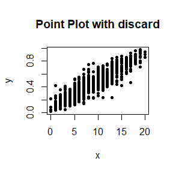

```r
plot(chain.new,type = "p",pch=20,main = "Point Plot with discard")
```

Then we use the Gelman-Rubin method to monitor convergence of the chain, and run the chain until it converges approximately to the target distribution according to $\hat{R}<1.2$.

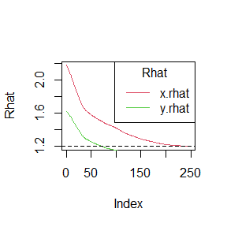

```r
set.seed(12003)
bi.chain<-function(a,b,n,N,x0){
## a, b, n is parameters
## N is the biggest length of chains
## x0 is the initial values, x0 is a 2*k matrix
  k<-ncol(x0)
  x.chain<-matrix(NA,k,N)
  y.chain<-matrix(NA,k,N)
  x.chain[,1]<-x0[1,]
  y.chain[,1]<-x0[2,]

  u<-matrix(runif(N*k),k,N)
  x.psi<-y.psi<-matrix(NA,k,N)
  x.psi[,1]<-x.chain[,1]
  y.psi[,1]<-y.chain[,1]
  Count<-1
  x.rhat<-y.rhat <- rep(0,N)

  for (i in 2:N) {
    for (j in 1:k) {
      yt<-y.chain[j,i-1]
      xt<-x.chain[j,i]<-rbinom(1,n,yt)
      y.chain[j,i]<-rbeta(1,xt+a,n-xt+b)
      x.psi[j,i]<-mean(x.chain[j,1:i])
      y.psi[j,i]<-mean(y.chain[j,1:i])
    }
    x.rhat[i]<-Gelman.Rubin(x.psi[,1:i])
    y.rhat[i]<-Gelman.Rubin(y.psi[,1:i])
    if(x.rhat[i]<=1.2&y.rhat[i]<=1.2) break;
    Count<-i
  }
  chain<-list(x.chain=x.chain[,1:Count],y.chain=y.chain[,1:Count])
  rhat<-list(x.rhat=x.rhat[1:Count],y.rhat=y.rhat[1:Count])
  return(list(chain=chain,rhat=rhat))
}
a<-2
b<-2
n<-20
N<-9000
burn<-100
x0<-matrix(c(0,0.2,10,0.2,10,0.8,20,0.5),2,4)
result_bi<-bi.chain(a,b,n,N,x0)
plot(result_bi$rhat$x.rhat[-(1:100)],type="l",ylab = "Rhat",col=2)
lines(result_bi$rhat$y.rhat[-(1:100)],col=3)
abline(h=1.2, lty=2)
legend("topright",legend = c("x.rhat","y.rhat"),lty = 1,col = c(2,3),title = "Rhat")
```

We choose 4 groups different initial values $(0,0.2),(10,0.2),(10,0.8),(20,0.5)$, and we stop running chains when both x.rhat and y.rhat are below 1.2, the stopping time is $t=$ 349.

# HW9

## Exercise 11.3

$(a)$ Write a function to compute the $k^{th}$ term in
$$\sum_{k=0}^{\infty}\frac{(-1)^k}{k!2^k}\frac{{||{a}||}^{2k+2}}{(2k+1)(2k+2)}\frac{\Gamma(\frac{d+1}{2})\Gamma(\frac{2k+3}{2})}{\Gamma(k+\frac{d}{2}+1)},$$
where $d b % 1$ is an integer, $a$ is a vector in $\mathbb{R}^d$, and $||{\cdot}||$ denotes the Euclidean norm. Perform the arithmetic so that the coefficients can be computed for (almost) arbitrarily large $k$ and $d$. $($This sum converges for all $a{\in}{\mathbb{R}}^d )$.

$(b)$ Modify the function so that it computes and returns the sum.

$(c)$ Evaluate the sum when $a = (1, 2)^T$ .

$\textbf{Sol.}$ First we write the function below.

```r
term.func<-function(k,a){
## a is a vector
  d<-length(a)
  l<-exp((2*k+2)*log(norm(a,type = "2"))-log(2*k+1)-log(2*k+2)-k*log(2)+lgamma((d+1)/2)+lgamma(k+1.5)-lgamma(k+d/2+1)-lgamma(k+1))
  b<-(-1)^k*l
  return(b)
}
term.func(2^5,c(1:(2^5)))
```

```
## [1] 1.100302e+73
```

```r
term.func(0,c(1,2))
```

```
## [1] 1.963495
```

$(b)$ We write the summary function below. We stop summary if the absolution of the $k^{th}$ term is less than `.Machine$double.neg.eps`.

```r
sum.func<-function(a){
  dis<-.Machine$double.neg.eps # convergence distance
  Sum<-0
  Count<-0
  for (k in 0:1000) {
    Sum1<-term.func(k,a)
    if(abs(Sum1)>dis){
      Sum<-Sum+Sum1
      Count<-Count+1
    }else{break;}
  }
  if(Count==1000) print("The convergence is very slow or fails!")
  return(Sum)
}
```

$(c)$

```r
a<-c(1,2)
R<-sum.func(a)
```

The sum is 1.532164.

## Exercise 11.5

Write a function to solve the equation
$$\frac{2\Gamma(\frac{k}{2})}{\sqrt{\pi(k-1)}\Gamma(\frac{k-1}{2})}{\int}_0^{c_{k-1}}\left(1+\frac{u^2}{k-1}\right)^{-k/2}du=\frac{2\Gamma(\frac{k+1}{2})}{\sqrt{\pi k}\Gamma(\frac{k}{2})}{\int}_0^{c_{k}}\left(1+\frac{u^2}{k}\right)^{-(k+1)/2}du$$
for $a$, where
$$c_k=\sqrt{\frac{a^2 k}{k+1-a^2}}.$$
Compare the solutions with the points $A(k)$ in Exercise 11.4.

$\textbf{Sol.}$ We first run Exercise 11.4.

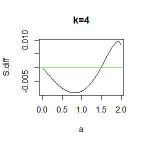

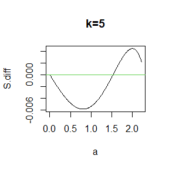

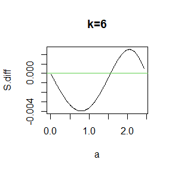

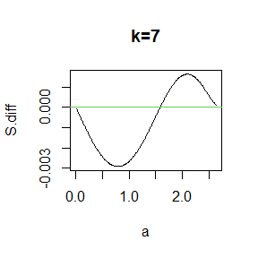

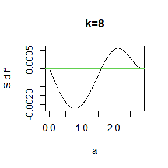

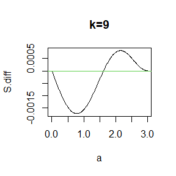

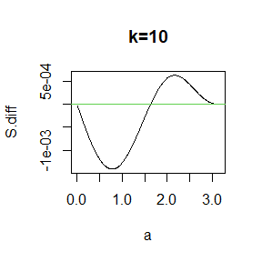

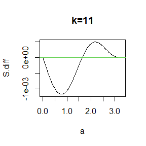

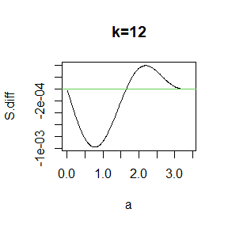

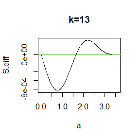

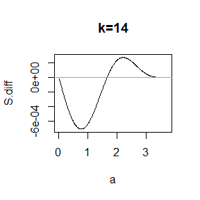

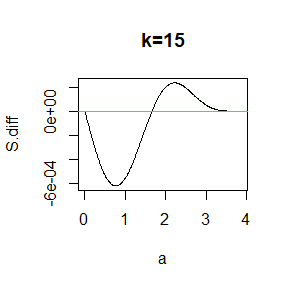

[13 more figures not shown]

```r
K<-c(4:25,100,500,1000)
Cka <- function(k,a) {
  sqrt(a^2*k/(k+1-a^2))
}
S.diff<-function(k,a){
  ## S_{k}(a)-S_{k-1}(a)
  pt(Cka(k-1,a),k-1)-pt(Cka(k,a),k)
}
#par(mfrow=c(3,3))
for (k in 1:length(K)) {
  N<-1000
  A<-seq(0.01,sqrt(K[k])-1e-3,0.01)
  N_A<-length(A)
  S<-rep(N_A)
  for (i in 1:N_A) {
    S[i]<-S.diff(K[k],A[i])
  }
  plot(A,y=S,type="l",xlim = c(0,A[N_A]),xlab = "a",ylab = "S.diff",main=paste0("k=",K[k]))
  abline(h=0,col=3)
}
```

We can see that for every $k$, there is a root between 0 and 4.

```r
Root<-data.frame(matrix(0,2,length(K)))
Root[1,]<-K
row.names(Root)<-c("k","root")
for (k in 1:length(K)) {
  Root[2,k]<-uniroot(function(a){S.diff(K[k],a)},lower = 1e-8,upper =min(sqrt(K[k])-1e-8,4))$root
}
knitr::kable(t(Root))
```

|  | k | root |
| --- | --- | --- |
| X1 | 4 | 1.492103 |
| X2 | 5 | 1.533548 |
| X3 | 6 | 1.562768 |
| X4 | 7 | 1.584421 |
| X5 | 8 | 1.601182 |
| X6 | 9 | 1.614517 |
| X7 | 10 | 1.625356 |
| X8 | 11 | 1.634391 |
| X9 | 12 | 1.642024 |
| X10 | 13 | 1.648561 |
| X11 | 14 | 1.654156 |
| X12 | 15 | 1.659096 |
| X13 | 16 | 1.663434 |
| X14 | 17 | 1.667305 |
| X15 | 18 | 1.670748 |
| X16 | 19 | 1.673841 |
| X17 | 20 | 1.676638 |
| X18 | 21 | 1.679178 |
| X19 | 22 | 1.681496 |
| X20 | 23 | 1.683620 |
| X21 | 24 | 1.685572 |
| X22 | 25 | 1.687374 |
| X23 | 100 | 1.720608 |
| X24 | 500 | 1.729756 |
| X25 | 1000 | 1.730908 |

```r
f<-function(k,a){
  lgamma((k+1)/2)-log(sqrt(pi*k))-lgamma(k/2)+log(integrate(function(u){(1+u^2/k)^(-(k+1)/2)},0,Cka(k,a))$value)-(lgamma(k/2)-log(sqrt(pi*(k-1)))-lgamma((k-1)/2)+log(integrate(function(u){(1+u^2/(k-1))^(-k/2)},0,Cka(k-1,a))$value))
}
Root.new<-data.frame(matrix(0,3,length(K)))
Root.new[1:2,]<-Root
for (k in 1:length(K)) {
  Root.new[3,k]<-uniroot(function(a){f(K[k],a)},upper =min(sqrt(K[k])-1e-3,3) ,lower =1e-8)$root
}
knitr::kable(t(Root.new),col.names = c("k","root_11.4","root_11.5"))
```

|  | k | root_11.4 | root_11.5 |
| --- | --- | --- | --- |
| X1 | 4 | 1.492103 | 1.492081 |
| X2 | 5 | 1.533548 | 1.533586 |
| X3 | 6 | 1.562768 | 1.562750 |
| X4 | 7 | 1.584421 | 1.584454 |
| X5 | 8 | 1.601182 | 1.601185 |
| X6 | 9 | 1.614517 | 1.614518 |
| X7 | 10 | 1.625356 | 1.625385 |
| X8 | 11 | 1.634391 | 1.634411 |
| X9 | 12 | 1.642024 | 1.642028 |
| X10 | 13 | 1.648561 | 1.648542 |
| X11 | 14 | 1.654156 | 1.654177 |
| X12 | 15 | 1.659096 | 1.659109 |
| X13 | 16 | 1.663434 | 1.663439 |
| X14 | 17 | 1.667305 | 1.667286 |
| X15 | 18 | 1.670748 | 1.670725 |
| X16 | 19 | 1.673841 | 1.673818 |
| X17 | 20 | 1.676638 | 1.676614 |
| X18 | 21 | 1.679178 | 1.679154 |
| X19 | 22 | 1.681496 | 1.681455 |
| X20 | 23 | 1.683620 | 1.683619 |
| X21 | 24 | 1.685572 | 1.685558 |
| X22 | 25 | 1.687374 | 1.687352 |
| X23 | 100 | 1.720608 | 1.720599 |
| X24 | 500 | 1.729756 | 1.729744 |
| X25 | 1000 | 1.730908 | 1.730896 |

For each $k$, the roots between two exercises are very similar.

## Problem 3

Suppose $T_1,{\cdots},T_n$ are $i.i.d.$ samples drawn from the exponential distribution with expectation $\lambda$. Those values greater than $\tau$ are not observed due to right censorship, so that the observed values are $Y_i = T_iI(T_i{\le}\tau) + {\tau}I(T_i > \tau)$, $i = 1,\cdots, n$. Suppose $\tau = 1$ and the observed $Y_i$ values are as follows:
$$0.54, 0.48, 0.33, 0.43, 1.00, 1.00, 0.91, 1.00, 0.21, 0.85$$
Use the E-M algorithm to estimate $\lambda$, compare your result with the observed data MLE (note: $Y_i$ follows a mixture distribution).

$\textbf{Sol.}$ The observed data is $(Y_1,Y_2,Y_3,Y_4,Y_5,Y_6,Y_7,Y_8,Y_9,Y_10)$ and the missing data is $(T_5,T_6,T_8)$. The true data is $(Y_1,Y_2,Y_3,Y_4,T_5,T_6,Y_7,T_8,Y_9,Y_{10})$, we reorder this data as $X=(X_1,\cdots,X_{10})$ where $(X_8,X_9,X_{10})=(T_5,T_6,T_8)$. Suppose the initial value is $\lambda_0$. The likelihood function is $L(\lambda)=\frac{1}{\lambda^{10}}exp(-\frac{1}{\lambda}\sum_i X_i)$. The log-likelihood is $l(\lambda)=-10log(\lambda)-\frac{1}{\lambda}\sum_i X_i$. Then we use EM algorithm:

$\textbf{E-step:}$
$$\begin{equation*}
\begin{aligned}
l(\lambda,\lambda_0,X_1,\cdots,X_7)&=E_{\lambda_0}[l(\lambda)|Y_1,\cdots,Y_{10}]\\
&=-10log(\lambda)-\frac{1}{\lambda}\sum_{i=1}^6 X_i-\frac{3}{\lambda}E_{\lambda_0}[T_5|Y_5]\\
&=-10log(\lambda)-\frac{1}{\lambda}\sum_{i=1}^6 X_i-\frac{3}{\lambda}(1+\lambda_0).
\end{aligned}
\end{equation*}$$

The last equation is true because $P_{\lambda_0}(T_5{\le}t|Y_5=1)=P_{\lambda_0}(T_5{\le}t,Y_5=1)/P_{\lambda_0}(Y_5=1)=(e^{1/\lambda_0}-e^{(1-t)/\lambda_0})I(t>1).$

$\textbf{M-step:}$ We maximize $l(\lambda,\lambda_0,X_1,\cdots,X_7)$ w.r.t. $\lambda_0$, then $\lambda_1=\frac{3+3\lambda_0+\sum_{i=1}^6X_i}{10}=\frac{3\lambda_0+\sum_i Y_i}{10}$.

Replace $\lambda_0$ with $\lambda_1$ until convergence.

Set $\lambda=\frac{3\lambda+\sum_i Y_i}{10}$ we can solve $\hat{\lambda}=\sum_i Y_i/7$. In R code we set $\lambda_0=1$.

```r
Y<-c(0.54, 0.48, 0.33, 0.43, 1.00, 1.00, 0.91, 1.00, 0.21, 0.85)
yo<-c(0.54, 0.48, 0.33, 0.43, 0.91,0.21, 0.85)
tol<-.Machine$double.eps^0.25
N<-100
lambda1<-lambda0<-1
for (i in 1:N) {
  lambda2<-(3*lambda1+sum(Y))/10
  if(abs(lambda2-lambda1)<tol){
    break
  }
  lambda1<-lambda2
}
print(list(lambda=lambda2,iter=i))
```

```
## $lambda
## [1] 0.9643117
##
## $iter
## [1] 6
```

Under the tolerance the estimation $\hat{\lambda}_{EM}$=0.9643117 and the iteration is 6. Then we use MLE with the observed data to estimate $\lambda$. The log-likelihood function is $l(\lambda)=-7log(\lambda)-(\sum_{i=1}^7X_i+3)$.

```r
mlogL<-function(lambda=1){
  return(-(-length(yo)*log(lambda)-(sum(yo)+3)/lambda))
}
library(stats4)
fit<-mle(mlogL)
print(fit@coef)
```

```
##    lambda
## 0.9642705
```

It shows that the $\hat{\lambda}_{MLE}$=0.9642705, and the absolute difference $|\hat{\lambda}_{MLE}-\hat{\lambda}_{EM}|$ is less than the tolerance.

# HW10

## Exercise 1 in Page204

Why are the following two invocations of `lapply()` equivalent?

```r
trims <- c(0, 0.1, 0.2, 0.5)
x <- rcauchy(100)
lapply(trims, function(trim) mean(x, trim = trim))
lapply(trims, mean, x = x)
```

$\textbf{Sol.}$ The first invocation means that in each loop, apply one value in `trims` to `function(trim) mean(x, trim = trim)`, then the result `mean(x,trim=trim)` is returned. The second invocation means that in each loop, apply one value in `trims` to function `mean`, other input in `mean()` is `x=x`, so it also returns `mean(x,trim=trim)`. Therefore, they both are equivalent.

## Exercise 5 in Page204

For each model in the previous two exercises, extract $R^2$ using the function below.

$\textbf{Sol.}$

```r
## formulas in Ex3
formulas <- list(
mpg ~ disp,
mpg ~ I(1 / disp),
mpg ~ disp + wt,
mpg ~ I(1 / disp) + wt
)
rsq <- function(mod) summary(mod)$r.squared
Lm<-lapply(formulas,lm,data=mtcars)
R2<-lapply(Lm, rsq)
print(unlist(R2)) # R square
```

```
## [1] 0.7183433 0.8596865 0.7809306 0.8838038
```

The we use model in Ex4.

```r
## bootstrap
bootstraps <- lapply(1:10, function(i) {
rows <- sample(1:nrow(mtcars), rep = TRUE)
mtcars[rows, ]
})

Lm2<-lapply(bootstraps, lm, formula=mpg~disp)
R2<-lapply(Lm2, rsq)
print(unlist(R2)) #R square
```

```
##  [1] 0.6919559 0.7981063 0.5494152 0.7502682 0.7840328 0.5590852 0.7486346
##  [8] 0.7010377 0.7658777 0.7872405
```

We has used models and function `lapply` to calculate $R^2$.

## Exercise 1 in Page214

Use `vapply()` to:

a) Compute the standard deviation of every column in a numeric data frame.

b) Compute the standard deviation of every numeric column in a mixed data frame. (Hint: you’ll need to use `vapply()` twice.)

$\textbf{Sol.}$ a) We use data `mtcars` to calculate the standard deviation.

```r
vapply(mtcars, sd, numeric(1))
```

```
##         mpg         cyl        disp          hp        drat          wt
##   6.0269481   1.7859216 123.9386938  68.5628685   0.5346787   0.9784574
##        qsec          vs          am        gear        carb
##   1.7869432   0.5040161   0.4989909   0.7378041   1.6152000
```

b) We make a data.frame with characters, numbers and factors, we first translate them to numeric, and then calculate the sd.

```r
mkdata<-data.frame(matrix(NA,5,3))
mkdata[,1]<-c("2","2","3","5","4")
mkdata[,2]<-rnorm(5)
mkdata[,3]<-as.factor(sample(c(0,1),5,replace = T))
colnames(mkdata)<-c("character","numeric","factor")
mkdata<-data.frame(vapply(mkdata, as.numeric ,numeric(5)))
vapply(mkdata,sd,numeric(1))
```

```
## character   numeric    factor
## 1.3038405 0.7100577 0.5477226
```

## Exercise 7 in Page214

Implement `mcsapply()`, a multicore version of `sapply()`. Can you implement `mcvapply()`, a parallel version of `vapply()`? Why or why not?

$\textbf{Sol.}$ We use `simplify2array` and `mclapply` to write the function `mcsapply`.

```r
library(parallel)
## By default mc.cores=2
mcsapply<-function (X, FUN, ..., simplify = TRUE, USE.NAMES = TRUE, mc.preschedule = TRUE,
 mc.set.seed = TRUE, mc.silent = FALSE, mc.cores = getOption("mc.cores", 2L),
  mc.cleanup = TRUE, mc.allow.recursive = TRUE, affinity.list = NULL )
{
  ## use mclapply to calculate answer with list structure
  answer <- mclapply(X = X, FUN = FUN, ...,mc.preschedule = mc.preschedule,
mc.set.seed = mc.set.seed, mc.silent = mc.silent, mc.cores = mc.cores,
  mc.cleanup = mc.cleanup, mc.allow.recursive = mc.allow.recursive, affinity.list = affinity.list)
  if (USE.NAMES && is.character(X) && is.null(names(answer)))
    names(answer) <- X
  if (!isFALSE(simplify) && length(answer))
    simplify2array(answer, higher = (simplify == "array")) # translate structure to vector
  else answer
}
## use data mtcars to check function
mcsapply(mtcars,mean)
```

Notice that it doesn’t work in Windows and my code is run in Centos.

We think we can’t implement `mcvapply` because the source code of `sapply` uses R function `lapply` but the source code of `vapply` doesn’t.

```r
vapply<-function (X, FUN, FUN.VALUE, ..., USE.NAMES = TRUE)
{
  FUN <- match.fun(FUN)
  if (!is.vector(X) || is.object(X))
    X <- as.list(X)
  .Internal(vapply(X, FUN, FUN.VALUE, USE.NAMES))
}
```

# HW11

## Exercise 1

Write an Rcpp function for Exercise 9.8 (page 278, Statistical Computing with R).

$\textbf{Sol.}$ The Rcpp function is shown as follow.

```r
library(Rcpp)
cppFunction('NumericMatrix gibbsC(int a, int b, int n, int N, int thin) {
  NumericMatrix mat(N, 2);
  double x = 0, y = 0.2;
  for(int i = 0; i < N; i++) {
    for(int j = 0; j < thin; j++) {
      x = rbinom(1, n, y)[0];
      y = rbeta(1, x + a, n - x + b)[0];
    }
    mat(i, 0) = x;
    mat(i, 1) = y;
  }
  return(mat);
}')
```

This `gibbsC` function output a matrix with $N$ samples, and $a,b,n,thin$ are parameters. Then we use this function to check whether it works.

```r
#cpp_dir<-'E:/Learn/Statistical Computing/Homework/A-21081-2021-12-02/'
#sourceCpp(paste0(cpp_dir,'gibbsC.cpp'))
a<-b<-2
n<-20
thin<-10
N<-2000
resultC<-gibbsC(a = a,b = b, n = n,N = N,thin = thin)
burn<-1000
## show last 20 samples
resultC[(N-20+1):N,]
```

```
##       [,1]      [,2]
##  [1,]   18 0.9011310
##  [2,]    4 0.2740931
##  [3,]   13 0.6302988
##  [4,]   11 0.7314905
##  [5,]   14 0.5997383
##  [6,]   10 0.4878044
##  [7,]    4 0.2601199
##  [8,]   12 0.7099099
##  [9,]   12 0.6465632
## [10,]    5 0.1757333
## [11,]    5 0.2089737
## [12,]   10 0.4829792
## [13,]   15 0.7516100
## [14,]    4 0.2738549
## [15,]   13 0.6731201
## [16,]    8 0.5013526
## [17,]   13 0.7646846
## [18,]   11 0.6409986
## [19,]    8 0.4938073
## [20,]   12 0.5474300
```

It works! Then we compare the corresponding generated random numbers with pure R language using the function `qqplot`. We first show the R function.

```r
## gibbsR
gibbsR <- function(a, b, n, N, thin) {
  mat <- matrix(nrow = N, ncol = 2)
  x <- 0
  y <- 0.2
  for (i in 1:N) {
    for (j in 1:thin) {
      x <- rbinom(1, n, y)
      y <- rbeta(1, x+a, n-x+b)
    }
    mat[i, ] <- c(x, y)
  }
  mat
}
```

Then we generate $N$ R samples and burn first 1000 samples, and finally plot QQ-plot of $x$ and $y$ respectivly.

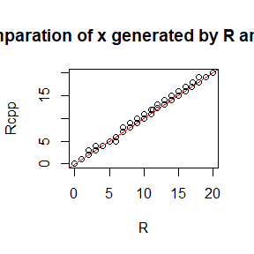

```r
#source(paste0(cpp_dir,'gibbsR.R'))
## generate samples
resultR<-gibbsR(a,b,n,N=N,thin = thin)
## burn first 100 samples
resultR<-resultR[(burn+1):N,]
resultC<-resultC[(burn+1):N,]
## plot
ap<-ppoints(100)
xC<-quantile(resultC[,1],ap)
xR<-quantile(resultR[,1],ap)
qqplot(x=xR,y=xC,xlab = "R",ylab = "Rcpp",
       main="Comparation of x generated by R and Rcpp ")
abline(0,1,col="red")
```

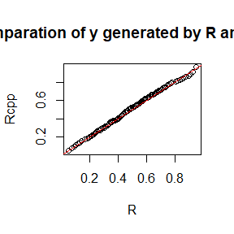

```r
yC<-quantile(resultC[,2],ap)
yR<-quantile(resultR[,2],ap)
qqplot(x=yR,y=yC,xlab = "R",ylab = "Rcpp",
       main="Comparation of y generated by R and Rcpp ")
abline(0,1,col="red")
```

They are very similar in QQ-plot below. Next we compare the computation time of the two functions with the function “microbenchmark”.

```r
library(microbenchmark)
ts <- microbenchmark(gibbR=gibbsR(a,b,n,N,thin),
gibbC=gibbsC(a,b,n,N,thin))
summary(ts)[,c(1,3,5,6)]
```

```
##    expr      lq   median       uq
## 1 gibbR 86.7576 88.68835 93.71225
## 2 gibbC  5.9533  6.00370  6.08135
```